# Technologie wytwarzania elementów urządzeń mechatronicznych

## TECHNIKI WYTWARZANIA POWŁOK

### Powłoki galwaniczne (złocenie)

[interactive chart not shown]

Gold Plating Services https://www.youtube.com/watch?v=EW0f3PrXdZQ

## TECHNIKI WYTWARZANIA POWŁOK

### Powłoki galwaniczne (Srebrzenie)

- Umożliwia wytworzenia powłoki o dużej odporności chemicznej i korozyjnej, z doskonałą przewodnością elektryczną i cieplną, także stykową.
- Na podłoża aluminiowe i inne metale.

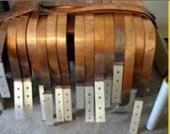

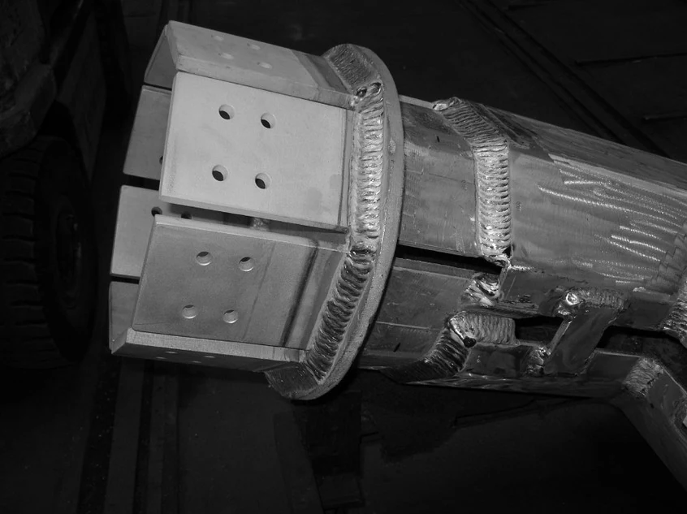

Elbit, UPRP

## TECHNIKI WYTWARZANIA POWŁOK

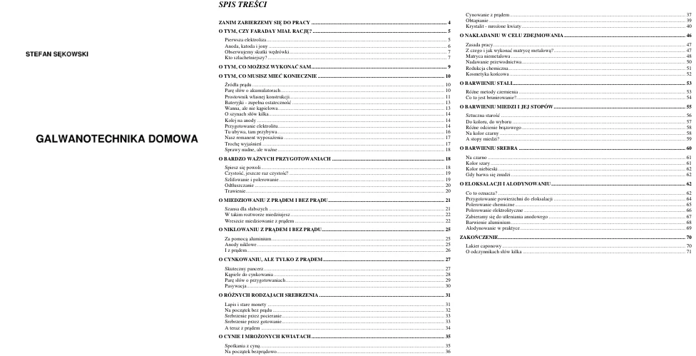

https://archive.org/embed/stefansekowski/1 Sękowski Stefan - Galwanotechnika domowa

## TECHNIKI WYTWARZANIA POWŁOK

### Powłoki galwaniczne (właściwości powłok)

Korozja elektrochemiczna (galwaniczna)

- Mikroogniwo na styku metali w środowisku elektrolitycznym
- Zn jest bardziej elektroujemny od Fe (aktywny chemicznie), chroni Fe elektrochemicznie, sam ulegając korozji. Powłoka zachowuje się jak anoda (roztwarza się) - powłoka anodowa.
- Ni chroni podłoże tylko mechanicznie, ale w przypadku przerwania powłoki, roztwarzaniu (korozji) ulega Fe - (Ni) powłoka katodowa. Warstwa pośrednia Cu zapewnia odporność (+0,34 V).

[figure not shown]

## TECHNIKI WYTWARZANIA POWŁOK

### Powłoki galwaniczne (właściwości powłok)

Naprężenia mechaniczne (własne) są przyczyną pękania powłok, odwarstwiania lub powstawania pęcherzy. Kontrolę rodzaju naprężeń prowadzi się pokrywając jednostronnie cienkie blaszki.  
Ni, Co, Rh, Mn, Cr: naprężenia rozciągające (+)  
Zn, Cd, Pb: naprężenia ściskające (-)  
Rodzaj i wartości naprężeń są związane z temperaturą topnienia metalu i różnym typem krystalizacji.

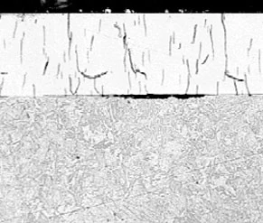

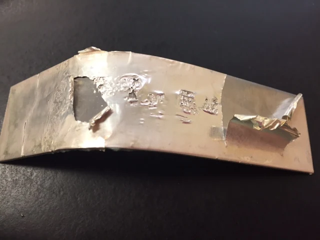

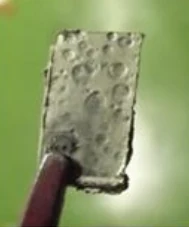

AZO Materials, Hudson Plating Works,; Whulanza Y., Mechanical Engineering 6.6 (2015).

## TECHNIKI WYTWARZANIA POWŁOK

### Powłoki konwersyjne

Powłoki niemetalowe, nieorganiczne (najczęściej tlenki metali lub związki z resztami kwasowymi), utworzone (elektro)chemicznie z udziałem metalu podłoża. Przejście metalu ze stanu wolnego do związku, czyli konwersja (stąd nazwa), w którym jest bardziej stabilny pod względem termodynamicznym.

Najważniejsze procesy:

- anodowe utlenianie Al (elektrolityczne)
- fosforanowanie stali
- utlenianie stali (oksydowanie)
- chromianowanie Al, Zn, Cd.

## TECHNIKI WYTWARZANIA POWŁOK

### Anodowanie

Wytworzenie warstwy Al<sub>2</sub>O<sub>3</sub> na powierzchni aluminium lub jego stopu z udziałem prądu elektrycznego.

- Przedmiot pokrywany: anoda (stąd nazwa).
- Elektrolit: wodny roztwór kwasu siarkowego.
- Katoda odporna chemicznie: Pb.

$$2\mathrm{Al}^{3+} + 3\mathrm{SO_4}^{2-} + 3\mathrm{H_2O}
\longrightarrow
\mathrm{Al_2O_3} + 3\mathrm{H_2SO_4}$$

Właściwości:

- Porowata powłoka nie spełnia funkcji zabezpieczającej przed wpływem czynników zewnętrznych.
- Można ją nasycać barwnikami organicznymi lub nieorganicznymi (T ≈ 60÷70°C).
- Uszczelnianie zasklepiające pory: 100°C H<sub>2</sub>O (1h) lub roztwory soli (minuty).
- Powłoki Al<sub>2</sub>O<sub>3</sub> są twarde, odporne na ścieranie odporne na korozję, estetyczne, kruche.
- Parametry technologiczne procesu: U = 10÷20 V, I<sub>f</sub> = 1,2÷1,5 A/dm<sup>2</sup> , T = 18÷20°C.

## TECHNIKI WYTWARZANIA POWŁOK

### Anodowanie

[figure not shown]

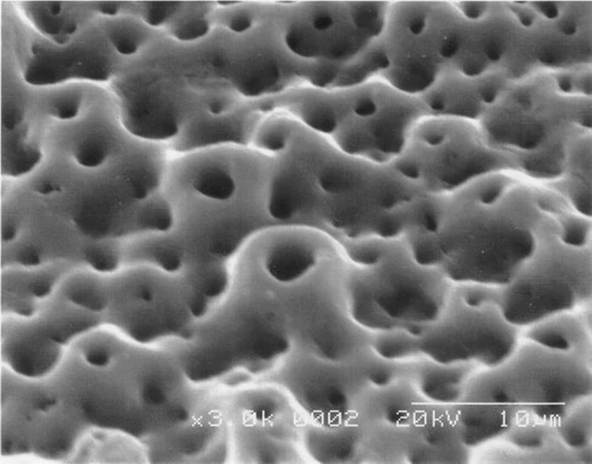

Wickwerks

## TECHNIKI WYTWARZANIA POWŁOK

### Fosforanowanie

- Wytworzenie powłoki FePO<sub>4</sub> (fosforanu żelazowego) oraz Fe<sub>2</sub>O<sub>3</sub>. (również dla Zn, Al i ich stopów)
- Zanurzeniu elementu w roztworze H<sub>3</sub>PO<sub>4</sub>.
- Budowa amorficzna (g 1÷1,5μm) lub krystaliczna (g 1÷20μm).
- Elastyczne, miękkie i dobrze związane z podłożem.
- Porowata powłoka i nie stanowi zabezpieczenia antykorozyjnego (olejowanie, woskowanie).
- Zastosowanie:
- podkład pod powłoki malarsko lakiernicze,
- powłoki elektroizolacyjne,
- powłoki przeciwcierne
- (blachy do przeróbki plastycznej, narzędzia, wkręty).

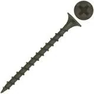

[figure not shown]

*Breaking Taps, Low-tech coating is a microscopic marvel* https://www.youtube.com/watch?v=O0-6g6NJMmE

Viega, Castorama

## TECHNIKI WYTWARZANIA POWŁOK

### Oksydowanie (czernienie)

- Chemiczne przekształcenie żelaza w najbardziej trwały tlenek Fe<sub>3</sub>O<sub>4</sub> (magnetyt).
- Proces wytwarzania:
- W stężonych roztworach NaOH, NaNO<sub>3</sub>, NaNO<sub>2</sub>
- Przygotowanie: odtłuszczanie, trawienie
- Utlenianie chemiczne
- Płukanie w ciepłym roztworze detergentów, suszenie, olejowanie lub woskowanie
- Zastosowanie: dekoracyjne, elementy przyrządów optycznych, broń, narzędzia.

[figure not shown]

[figure not shown]

[figure not shown]

Lodge, Browning, Beta

## TECHNIKI WYTWARZANIA POWŁOK

### Chromianowanie

- Pasywna powłoka tlenków Cr na detalach metalowych.
- Znacznie poprawia odporność na korozję, zachowując wytrzymałość mechaniczną i termiczną.
- Na elementy Zn, Cd, Cu, Ag, Mg, Al i wybrane stopy tych metali.
- Grubość 0,1÷1 μm.
- Przed wysuszeniem (po procesie) jest porowata.
- Roztwory CrO<sub>3</sub> + Na<sub>2</sub>SO<sub>4</sub> + H<sub>2</sub>O, temperatura pokojowa, kilka minut.
- Zastosowanie: ochronne i dekoracyjne (barwienie), podkład pod powłoki malarskie.

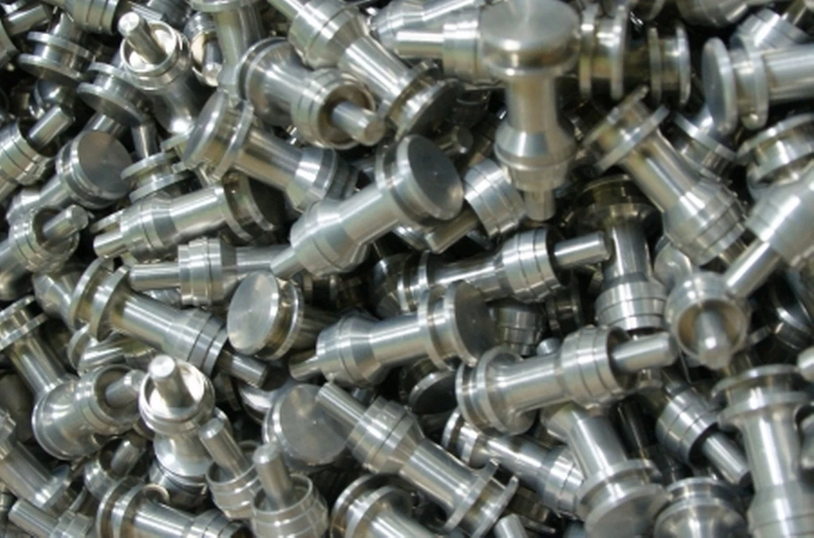

[figure not shown]

ECM

## QUIZ

- Podobieństwa i różnice polerowania i powlekania elektrochemicznego.
- Jakie zjawiska zachodzą w trawieniu i miedziowaniu elektrochemicznym?
- Podczas procesu galwanostegii (lub galwanoplastyki) można prowadzić trawienie elektrochemiczne?
- Czy w chromowaniu technicznym elementów wytwarzamy twardą warstwę tlenku chromu?
- Kiedy i dla jakich materiałów można prowadzić proces utleniania?